# 深度学习动手实验

## 任务介绍——手写数字识别

MNIST数据集是一个有名的手写数字数据集，在深度学习领域，手写数字识别是一个很经典的学习例子。MNIST数据集来自美国国家标准与技术研究所，是NIST(National Institute of Standards and Technology)的缩小版，训练集（training set）由来自250个不同人手写的数字构成，其中50%是高中学生，50%来自人口普查局（the Census Bureau）的工作人员，测试集（test set）也是同样比例的手写数字数据。

[figure not shown]

## 具体说明

[figure not shown]

[output not shown]

## 环境说明

- 系统要求：Windows、Linux、UNIX都可以
- 快速安装：Anaconda，Nvidia-CUDA
- 编程语言：python，C/C++
- 代码环境：jupyter-notebook，vscode，pycharm
- 依赖环境：numpy（科学计算），pytorch（深度学习），matplotlib（可视化）
- 可选环境：torchvision（数据集，模型结构、图片转换工具）

```python
import torch
import numpy as np
import matplotlib.pyplot as plt

import torch.nn as nn
from torchvision import datasets, transforms
from torch.utils.data import Dataset, DataLoader
```

## 三个模块

- dataset：数据库
- network：网络结构
- train：网络训练

### dataset模块

- 继承 torch.utils.data.Dataset
- 三个关键函数（init，len，getitem）
- init 中一般定义 数据库路径、数据预处理方法和数据增强方法
- len 返回数据数量
- getitem 接受index，并返回对应的data

```python
# 继承torch.utils.data.Dataset
class clf_dataset(Dataset):

    def __init__(self):
        # initialization
        pass

    def __len__(self):
        # return int
        pass

    def __getitem__(self, index):
        # return np.ndarray or torch.tensor
        pass
```

```python
# torchvision中带有MNIST数据集
test_dataset = datasets.MNIST(root='./Dataset',
                              train=True,
                              transform=transforms.ToTensor(),
                              download=True)
```

### Tips

- torchvision中整合了常用的数据集，初学者可以轻松调用，减少数据采集、清洗和使用过程中的工作量
- Dataset是机器学习的关键点，数据库的构建需要花费大量精力。
- 数据库很可能影响最终结果。

常用的数据集

| 名称 | 说明 |
| --- | --- |
| Imagenet | 耗费100万美金收集了1400多万幅图片，涵盖2万多个类别。在计算机视觉领域研究论文中应用非常广。 |
| COCO | 图像识别、分割和图像语义数据集 |
| VOC | 视觉对象的分类识别和检测的一个基准测试，提供了检测算法和学习性能的标准图像注释数据集和标准的评估系统。 |
| CIFAR | 对于图像分类算法测试来说是一个非常不错的中小规模数据集 |

### network模块

- 继承 torch.nn.Module
- 定义网络正向传播过程
- 网络权重的初始化

```python
# 继承 torch.nn.Module
class clf_network(nn.Module):

    # 初始化
    def __init__(self):
        super().__init__()# 继承父类初始化
        self.network = nn.Sequential(
            nn.Conv2d(1, 3, kernel_size=3, padding=1),
            nn.ReLU(inplace=True),
            nn.MaxPool2d(kernel_size=2, stride=2, padding=0),
            nn.Conv2d(3, 5, kernel_size = 3, padding=1),
            nn.ReLU(inplace=True),
            nn.MaxPool2d(kernel_size=2, stride=2, padding=0),
            nn.Conv2d(5, 10, kernel_size=7, padding=0),
            nn.Flatten()
        )

    # 正向传播
    def forward(self, input_img):
        return self.network(input_img)

    # 权重初始化
    def _initialize_weights(self):
#         for m in self.modules():
#             if isinstance(m, nn.Conv2d):
#                 n = m.kernel_size[0] * m.kernel_size[1] * m.out_channels
#                 m.weight.data.normal_(0, math.sqrt(2. / n))
#                 if m.bias is not None:
#                     m.bias.data.zero_()
#             elif isinstance(m, nn.BatchNorm2d):
#                 m.weight.data.fill_(1)
#                 m.bias.data.zero_()
#             elif isinstance(m, nn.Linear):
#                 m.weight.data.normal_(0, 0.01)
#                 m.bias.data.zero_()
        pass
```

### Tips

- 权重初始化很重要
- 超参数调节需要经验
- 熟悉各种经典网络结构，有助于自己设计神经网络
- 经典神经网络：LeNet, AlexNet, NiN，GoogLeNet, VGG, ResNet, DenseNet

### train模块

定义神经网络的训练过程

Softmax $$S_i = \frac{e^i}{\sum_j{e^j}}$$

```python
class train():

    def __init__(self):

        self.batch_size = 8 # 每一轮训练的数据量
        self.shuffle = True # 随机打乱数据集
        self.num_workers = 1 # 参与数据准备的核心数

        self.device = torch.device('cuda' if torch.cuda.is_available() else 'cpu') # 训练部署在CPU或者GPU
        self.net = clf_network()
        self.net.to(self.device)

        # MNIST
        train_dataset = datasets.MNIST(root='./Dataset', train=True, transform=transforms.ToTensor(), download=True)
        valid_dataset = datasets.MNIST(root='./Dataset', train=False, transform=transforms.ToTensor(), download=True)

        self.train_dataset_loader = DataLoader(train_dataset, shuffle=self.shuffle, batch_size=self.batch_size, num_workers=self.num_workers)
        self.valid_dataset_loader = DataLoader(valid_dataset, shuffle=self.shuffle, batch_size=self.batch_size, num_workers=self.num_workers)

        self.train_acc_list = []
        self.valid_acc_list = []
        self.train_loss_list = []
        self.valid_loss_list = []

    def save(self):
        torch.save(self.net.state_dict(), './Model/clf_network.pth')

    def load(self):
        self.net.load_state_dict(torch.load('./Model/clf_network.pth', map_location='cpu'))
        self.net.to(self.device)

    def save_txt(self):
#         save self.train_acc_list
#         save self.valid_acc_list
#         save self.train_loss_list
#         save self.valid_loss_list
        pass

    def train_net(self):

        # 训练模式，针对batchnorm、dropout等层
        self.net.train()

        # 样本量，准确率，损失
        epoch_n, epoch_acc, epoch_loss = 0, 0.0, 0.0

        # Adam优化器
        optimizer = torch.optim.Adam(self.net.parameters(), lr=0.001)

        # 交叉墒损失函数
        loss_func = torch.nn.CrossEntropyLoss()

        # 遍历数据库
        # img.shape = [batch_size, color_channels, img_H, img_W]
        # true_label.shape = [batch_size, label_channels]
        for img, true_label in self.train_dataset_loader:
            img = img.to(self.device).float()
            true_label = true_label.to(self.device)
            fake_label = self.net(img)
            loss = loss_func(fake_label, true_label)

            optimizer.zero_grad()
            loss.backward()
            optimizer.step()

            fake_label = nn.functional.softmax(fake_label, dim=1)
            fake_label = fake_label.argmax(dim=1)
            true_label = true_label.detach().cpu().numpy()
            fake_label = fake_label.detach().cpu().numpy()
            batch_acc = (true_label == fake_label).sum()
            batch_loss = loss.detach().cpu().numpy()

            epoch_n = epoch_n + int(img.shape[0])
            epoch_acc = epoch_acc + batch_acc
            epoch_loss = epoch_loss + batch_loss

        epoch_acc = epoch_acc / epoch_n
        epoch_loss = epoch_loss / epoch_n

        self.train_acc_list.append(epoch_acc)
        self.train_loss_list.append(epoch_loss)

        print("**********")
        print("task in train")
        print("epoch_n = " + str(epoch_n))
        print("epoch_acc = " + str(epoch_acc))
        print("epoch_loss = " + str(epoch_loss))
        print("**********")

    def valid_net(self):

        # 验证模式，针对batchnorm、dropout等层
        self.net.eval()

        # 样本量，准确率，损失
        epoch_n, epoch_acc, epoch_loss = 0, 0.0, 0.0

        # 交叉墒损失函数
        loss_func = torch.nn.CrossEntropyLoss()

        # 不记录梯度，节省资源
        with torch.no_grad():
            for img, true_label in self.valid_dataset_loader:
                img = img.to(self.device).float()
                true_label = true_label.to(self.device)
                fake_label = self.net(img)
                loss = loss_func(fake_label, true_label)

                fake_label = nn.functional.softmax(fake_label, dim=1)
                fake_label = fake_label.argmax(dim=1)
                true_label = true_label.detach().cpu().numpy()
                fake_label = fake_label.detach().cpu().numpy()
                batch_acc = (true_label == fake_label).sum()
                batch_loss = loss.detach().cpu().numpy()

                epoch_n = epoch_n + int(img.shape[0])
                epoch_acc = epoch_acc + batch_acc
                epoch_loss = epoch_loss + batch_loss

        epoch_acc = epoch_acc / epoch_n
        epoch_loss = epoch_loss / epoch_n

        self.valid_acc_list.append(epoch_acc)
        self.valid_loss_list.append(epoch_loss)

        print("**********")
        print("task in valid")
        print("epoch_n = " + str(epoch_n))
        print("epoch_acc = " + str(epoch_acc))
        print("epoch_loss = " + str(epoch_loss))
        print("**********")

    def drawplt(self):
        plt.clf()
        plt.figure(figsize=(10, 5), dpi=300)
        plt.subplot(1, 2, 1)
        plt.plot(np.arange(len(self.train_acc_list)), np.array(self.train_acc_list), label='Train Acc')
        plt.plot(np.arange(len(self.valid_acc_list)), np.array(self.valid_acc_list), label='Valid Acc')
        plt.xlabel('Epoches')
        plt.legend(loc='lower right')
        plt.subplot(1, 2, 2)
        plt.plot(np.arange(len(self.train_loss_list)), np.array(self.train_loss_list), label='Train Loss')
        plt.plot(np.arange(len(self.valid_loss_list)), np.array(self.valid_loss_list), label='Valid Loss')
        plt.xlabel('Epoches')
        plt.legend(loc='upper right')
        plt.show()
```

```
**********
task in train
epoch_n = 60000
epoch_acc = 0.9132666666666667
epoch_loss = 0.035727353154411924
**********
**********
task in valid
epoch_n = 10000
epoch_acc = 0.9642
epoch_loss = 0.014743747664478724
**********
```

[figure not shown]

```
**********
task in train
epoch_n = 60000
epoch_acc = 0.9641833333333333
epoch_loss = 0.014590511115496096
**********
**********
task in valid
epoch_n = 10000
epoch_acc = 0.9717
epoch_loss = 0.011408009878409212
**********
```

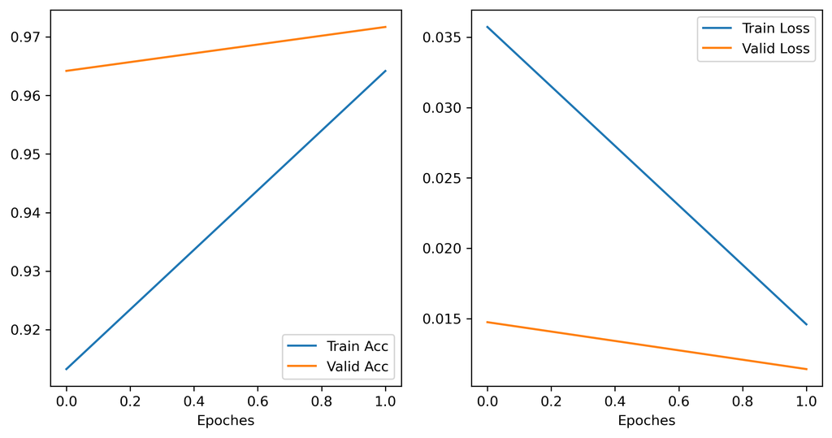

```
**********
task in train
epoch_n = 60000
epoch_acc = 0.9714333333333334
epoch_loss = 0.011585463249587338
**********
**********
task in valid
epoch_n = 10000
epoch_acc = 0.9738
epoch_loss = 0.010135506731243549
**********
```

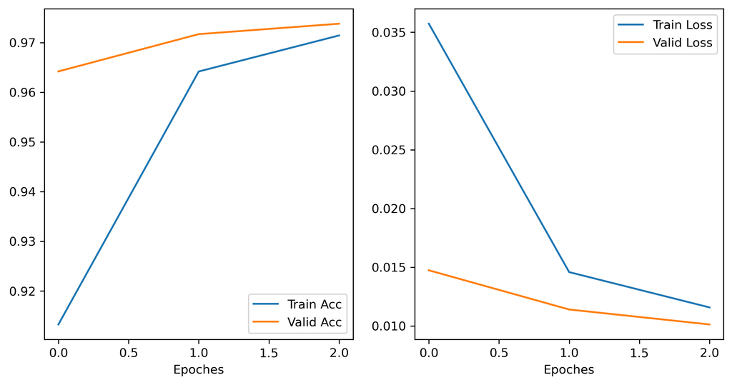

```
**********
task in train
epoch_n = 60000
epoch_acc = 0.9753833333333334
epoch_loss = 0.010129749791962817
**********
**********
task in valid
epoch_n = 10000
epoch_acc = 0.9765
epoch_loss = 0.009202542359211656
**********
```

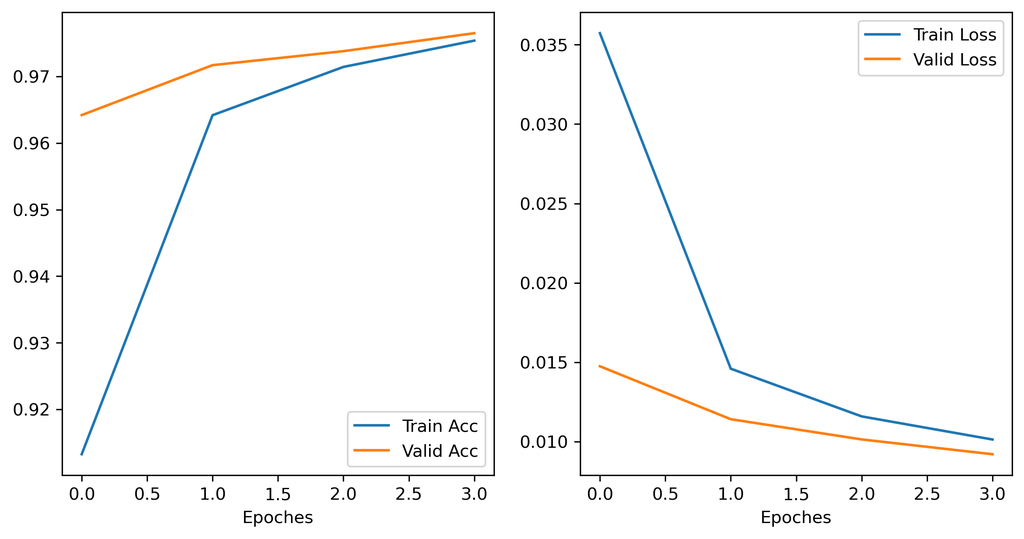

```
**********
task in train
epoch_n = 60000
epoch_acc = 0.9765666666666667
epoch_loss = 0.00931121730924145
**********
**********
task in valid
epoch_n = 10000
epoch_acc = 0.9756
epoch_loss = 0.009245380257682336
**********
```

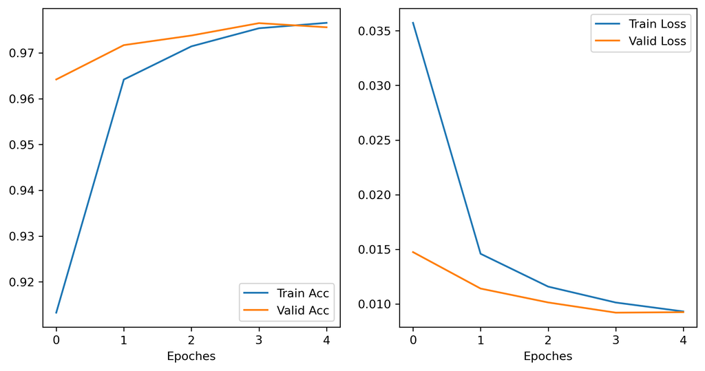

```
**********
task in train
epoch_n = 60000
epoch_acc = 0.9780666666666666
epoch_loss = 0.008806424785630436
**********
**********
task in valid
epoch_n = 10000
epoch_acc = 0.9759
epoch_loss = 0.009290148219687398
**********
```

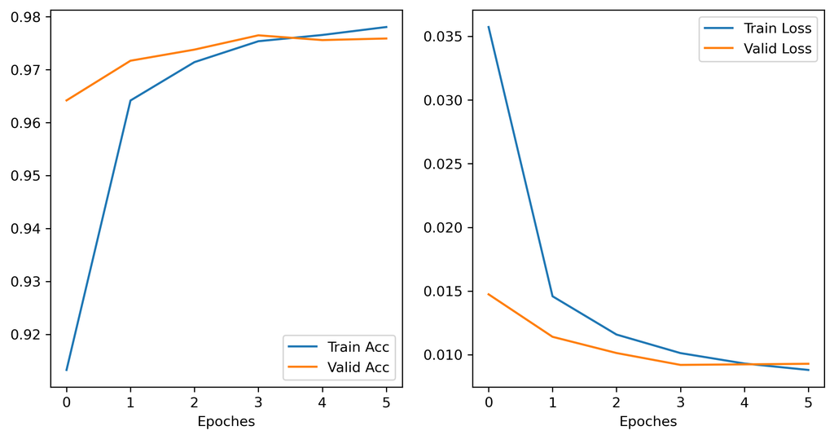

```
**********
task in train
epoch_n = 60000
epoch_acc = 0.9788
epoch_loss = 0.008404527038792185
**********
**********
task in valid
epoch_n = 10000
epoch_acc = 0.9795
epoch_loss = 0.008112624604455413
**********
```

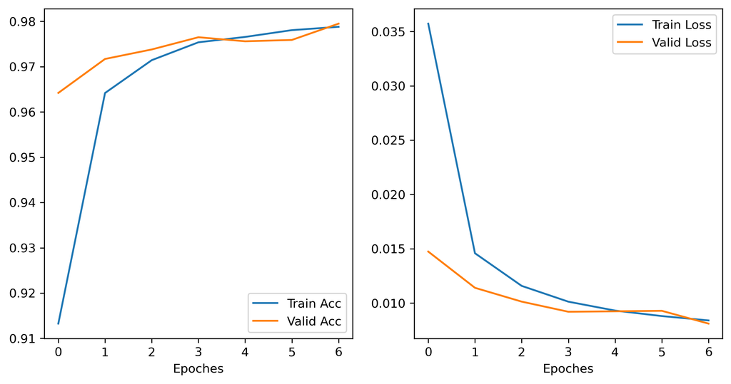

```
**********
task in train
epoch_n = 60000
epoch_acc = 0.9801166666666666
epoch_loss = 0.008028425235510546
**********
**********
task in valid
epoch_n = 10000
epoch_acc = 0.976
epoch_loss = 0.009304192409959432
**********
```

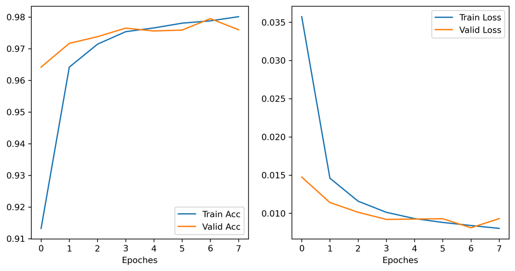

```
**********
task in train
epoch_n = 60000
epoch_acc = 0.9801833333333333
epoch_loss = 0.007755033814106021
**********
**********
task in valid
epoch_n = 10000
epoch_acc = 0.9803
epoch_loss = 0.007538235882918889
**********
```

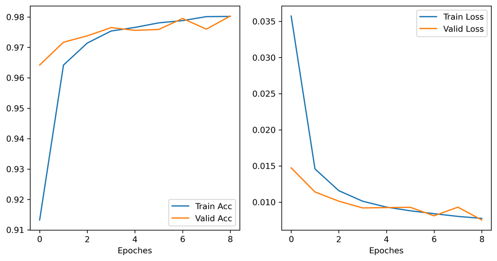

```
**********
task in train
epoch_n = 60000
epoch_acc = 0.9816833333333334
epoch_loss = 0.007432831835534648
**********
**********
task in valid
epoch_n = 10000
epoch_acc = 0.9812
epoch_loss = 0.007403236812791692
**********
```

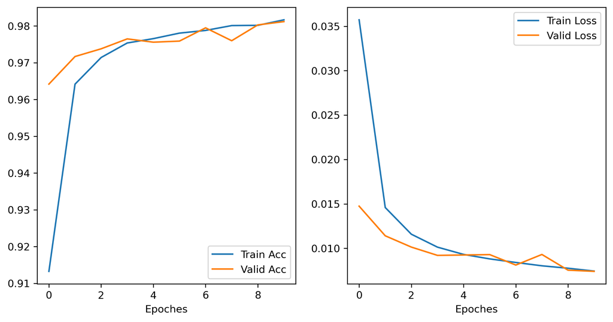

```python
# 课堂演示DEMO
demo = train()
for epoch in range(10):
    demo.train_net()
    demo.valid_net()
    demo.drawplt()
```

```
**********
task in valid
epoch_n = 10000
epoch_acc = 0.1028
epoch_loss = 0.2885654656410217
**********
```

[figure not shown]

```
**********
task in valid
epoch_n = 10000
epoch_acc = 0.1028
epoch_loss = 0.28856546523571014
**********
```

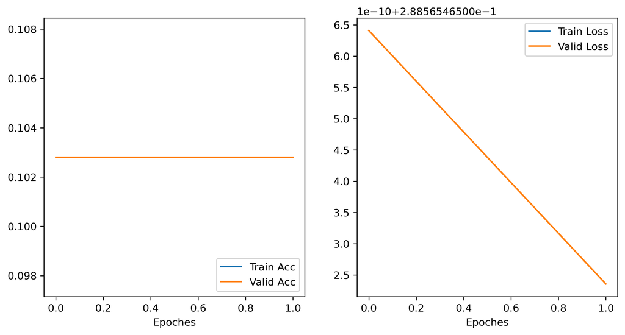

```
**********
task in valid
epoch_n = 10000
epoch_acc = 0.1028
epoch_loss = 0.28856546556949614
**********
```

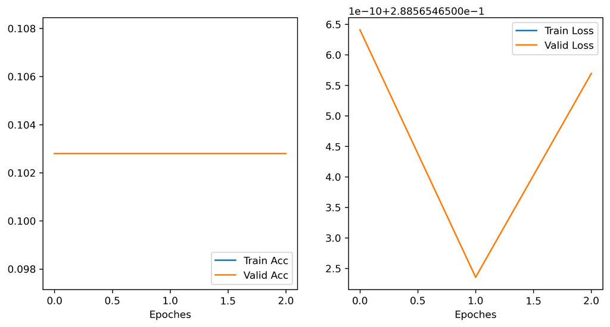

```
**********
task in valid
epoch_n = 10000
epoch_acc = 0.1028
epoch_loss = 0.28856546585559845
**********
```

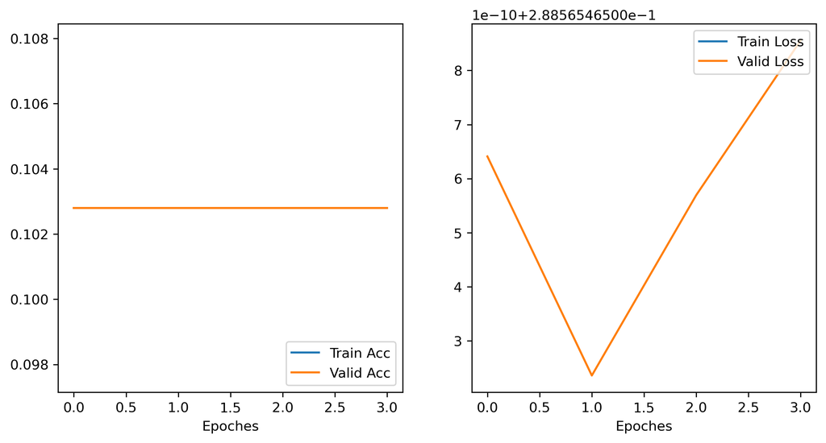

```
**********
task in valid
epoch_n = 10000
epoch_acc = 0.1028
epoch_loss = 0.28856546573638914
**********
```

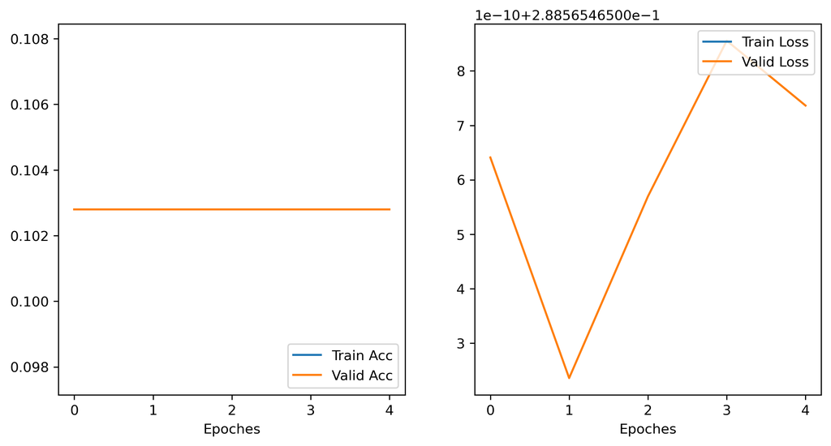

```
**********
task in valid
epoch_n = 10000
epoch_acc = 0.1028
epoch_loss = 0.28856546494960783
**********
```

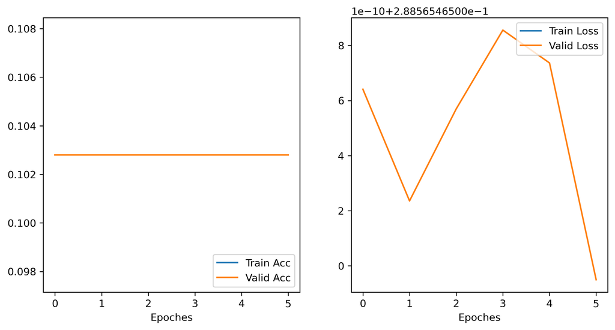

```
**********
task in valid
epoch_n = 10000
epoch_acc = 0.1028
epoch_loss = 0.28856546573638914
**********
```

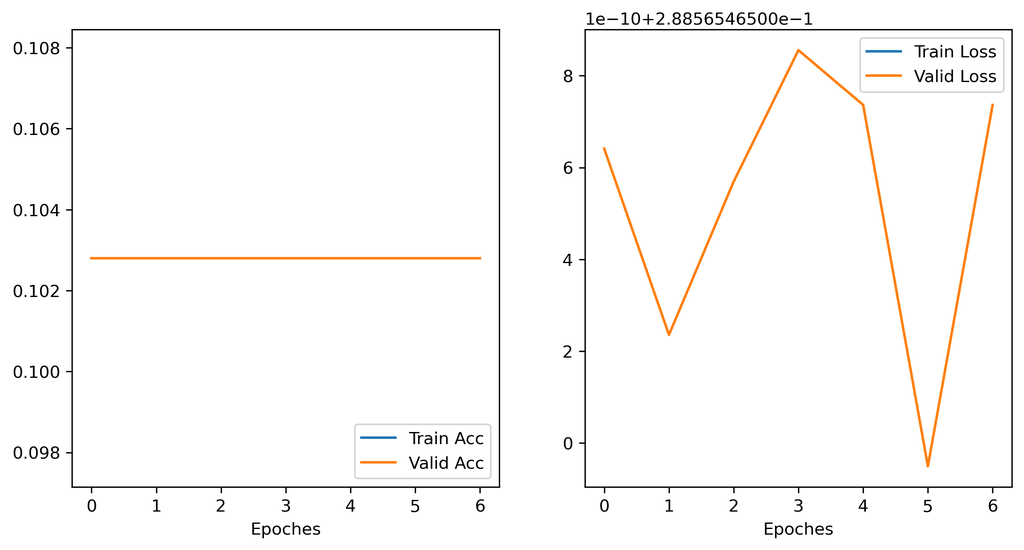

```
**********
task in valid
epoch_n = 10000
epoch_acc = 0.1028
epoch_loss = 0.28856546573638914
**********
```

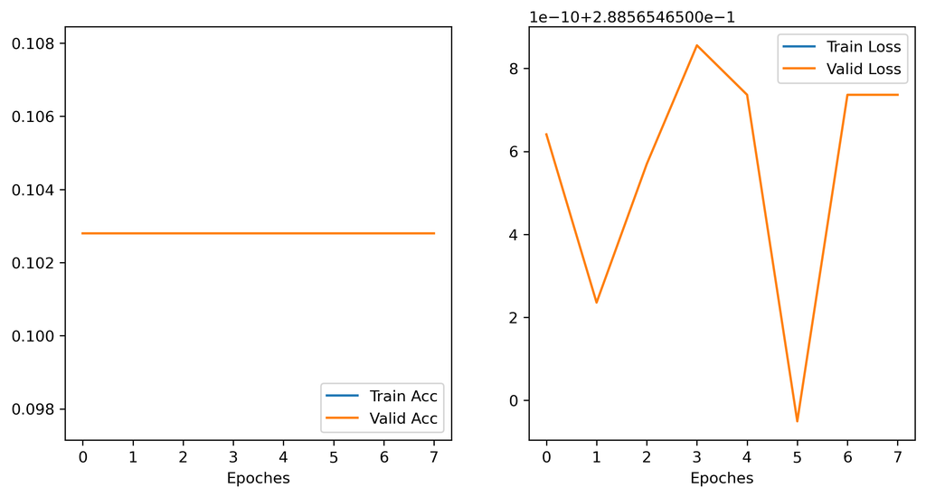

```
**********
task in valid
epoch_n = 10000
epoch_acc = 0.1028
epoch_loss = 0.2885654654741287
**********
```

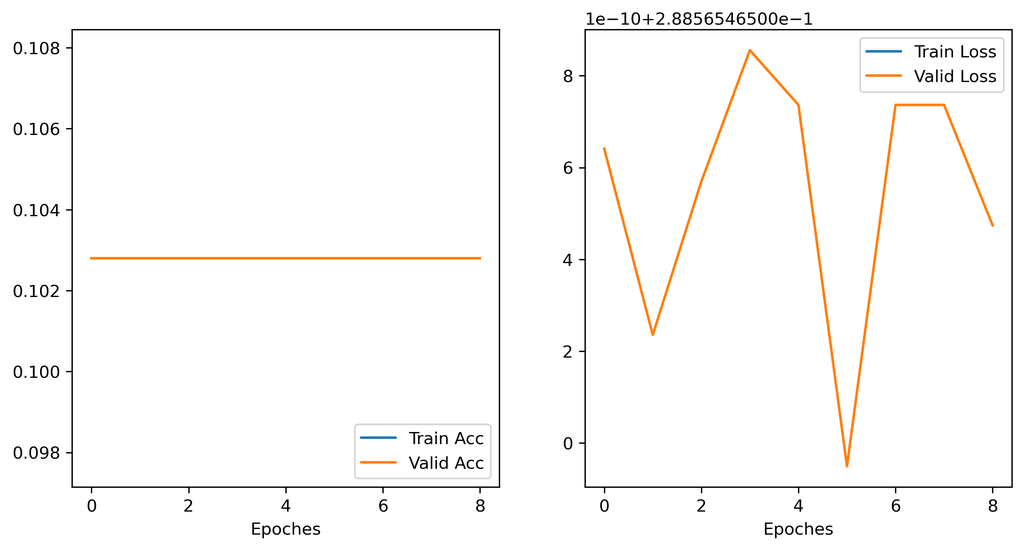

```
**********
task in valid
epoch_n = 10000
epoch_acc = 0.1028
epoch_loss = 0.288565465593338
**********
```

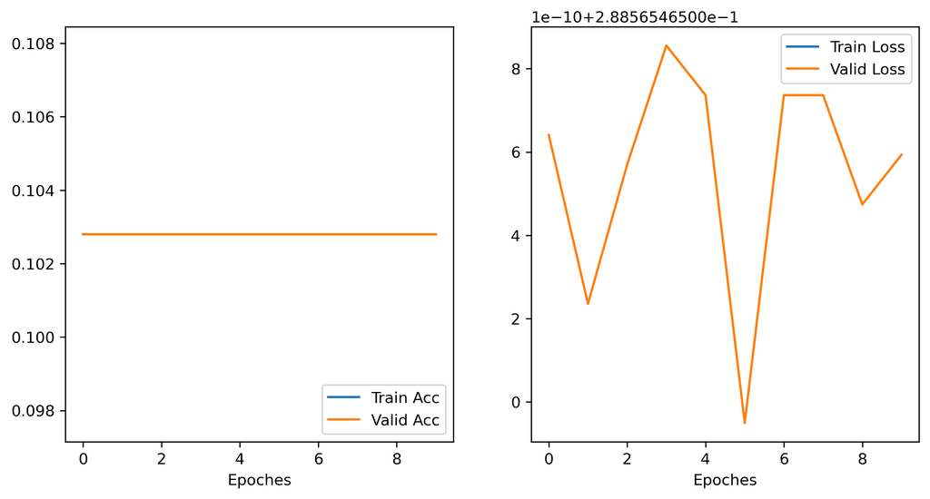

```python
demo = train()
for epoch in range(10):
#     demo.train_net()
    demo.valid_net()
    demo.drawplt()
```

### Tips

- 训练可以部署到GPU，加速效果可以达到10～100倍,甚至更高。
- batch_size, num_workers, shuffle影响训练过程，也影响训练结果
- 优化器常用的有SGD和Adam
- 损失函数非常重要，可以根据任务需求选择，也可以自己设计
- 学习率非常重要，太小则训练缓慢，太大则训练难收敛
- 熟悉训练过程中出现的各种问题，例如梯度消失、梯度爆炸、过拟合、欠拟合。

## 后续

### 推荐关注

[figure not shown]

### 免费GPU

Google Colab https://colab.research.google.com/notebooks/welcome.ipynb

### 本课程代码

GitHub链接 https://github.com/Deng-Xutian/2022_whu_deep_learning.git

[figure not shown]